# The Simulacrum

queueing really.

CH13 of [RA]

Excercises: 13.13, 13.16 Cases: 13.1, 13.2

#### Variables of a q system:

lambda - arrival rate (units/time period)  
mu - service rate (units/time period, per server)  
s, or c in our examples - number of servers

#### Parameters of a queueing system that we need:

- U - utilization factor. denoted as rho below
- P0 - probability that system is empty
- L_q - average number in line
- L - average number in system
- W_q - average time in line
- W average time in system
- P_w - probability of having to wait in line
- P_n - probability of n units in the system

#### Implementation with R

```r
rexp(1:5)
```

```
[1] 0.37972067 1.04064857 0.04885956 0.69002326 1.18605443
```

## A M/M/c system with unlimited queue / clients

```r
#setting up the environment
library(simmer)
#the basic parameters for a M/M/c system
lambda <- 60
mu <- 24
c<- 3
rho <- lambda/mu
#total utilization with multiple servers
rho_c <- lambda/(c*mu)
#set up the function that the servers use
mmc.trajectory <- trajectory() %>%
  seize("resource", amount=1) %>%
  timeout(function() rexp(1, mu)) %>%
  release("resource", amount=1)
#set up the environment with the arrival / server fuctions
#as you see exponential distributions around mu and lambda are chosen
mmc.env <- simmer() %>%
  #note that you can input the queue length here. right now set to infinite.
  add_resource("resource", capacity=c, queue_size=Inf) %>%
  add_generator("arrival", mmc.trajectory, function() rexp(1, lambda)) %>%
  run(until=200)
```

System stats (formulas from p.649, CH13.6.1 of Ragsdale):

```r
library(simmer.plot)
# Theoretical values
ind <- 0:(c-1)
#probability of empty
pi_0 <-1/(sum(rho**ind/factorial(ind)) + (rho**c/factorial(c))*(1/(1-rho/c)))
#average number in system
mmc.L <- rho +  ((rho**c/factorial(c))*pi_0)*((rho/c)/((1-rho/c)**2))
#average number in queue
mmc.Lq <- mmc.L - rho
```

Average waiting time and avg time in system:

```r
mmc.arrivals <- get_mon_arrivals(mmc.env)
mmc.resources<- get_mon_resources(mmc.env)
#avg time in system
mmc.t_system <- mmc.arrivals$end_time - mmc.arrivals$start_time
lambda_eff<-lambda
#avg wait time
mmc.W <- mmc.L / lambda_eff
mmc.W ; mean(mmc.t_system)
```

```
[1] 0.1001873
[1] 0.09017612
```

We are still missing the probabilities (of n units in system etc.)

```r
#probability of having to wait in line (of line being non-zero?)
p_w <- 1/factorial(c)*(lambda/mu)^c*(c*mu/(c*mu-lambda))*pi_0
#probability of n units in the system. set nunits to your value
nunits <- 2
p_n <- ((lambda/mu)^nunits)/factorial(nunits)*pi_0
#if n>s, another formula applies. Mind not to run the whole code chunk, but the individual lines. otherwise you'll only get the second result ^_^
nunitsm <- 1:100
p_n <- ((lambda/mu)^nunitsm)/(c*factorial(c)^(nunitsm-c))*pi_0
#we can plot the probabilities of a number of units in the system (or in queue). We have two formulas, so we need a loop. Ugly solution below
probabilities_units <- as.data.frame(cbind(nunitsm,p_n <- ((lambda/mu)^nunitsm)/(c*factorial(c)^(nunitsm-c))*pi_0))
#now we need the probabilities for when its less than c,(amount of servers)
for (ci in 1:c) {
   probabilities_units$V2[ci] <- ((lambda/mu)^ci)/factorial(ci)*pi_0
}
```

What about visualization?

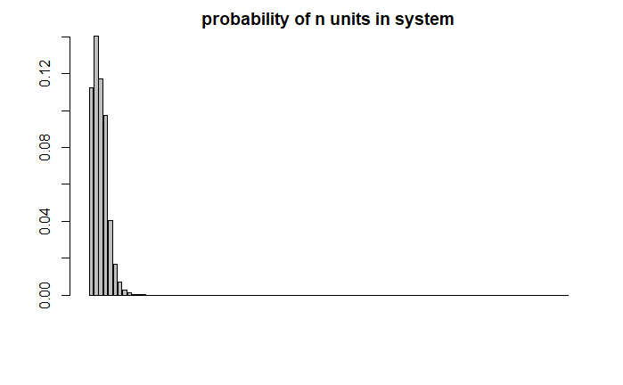

```r
#a barplot of probabilities of n units in system
barplot(probabilities_units$V2,main="probability of n units in system")
```

```
'plot.simmer' is deprecated.
Use 'plot(get_mon_resources(x))' instead.
See help("Deprecated")
```

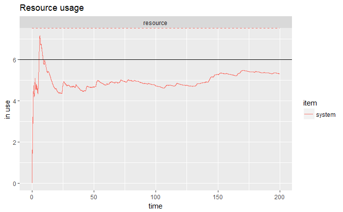

```r
# Evolution of the average number of customers in the system
plot(mmc.env, "resources", "usage", "resource", items="system") +
  geom_hline(yintercept=mmc.L) #+ ylim(0, 15)
```

```
'plot.simmer' is deprecated.
Use 'plot(get_mon_resources(x))' instead.
See help("Deprecated")
```

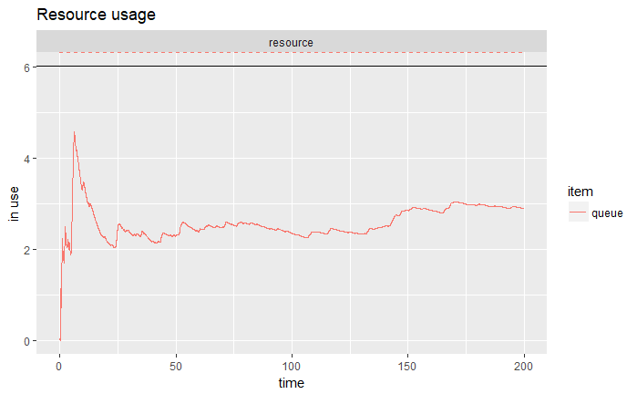

```r
#same but in queue
plot(mmc.env, "resources", "usage", "resource", items="queue") +
  geom_hline(yintercept=mmc.L) #+ ylim(0, 15)
```

```
'plot.simmer' is deprecated.
Use 'plot(get_mon_resources(x))' instead.
See help("Deprecated")
```

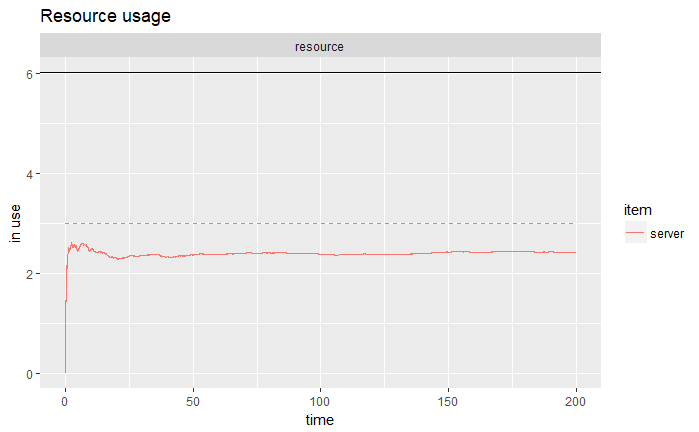

```r
#same but for how many servers are used
plot(mmc.env, "resources", "usage", "resource", items="server") +
  geom_hline(yintercept=mmc.L) #+ ylim(0, 15)
```

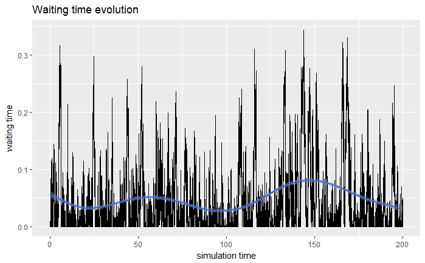

```r
#you can play with the Y-axis of the chart by removing the comment sign before + ylim(..). If your graph area becomes to small, the line will get broken + error messages. :)
#plot the average waiting time for arrivals!
#remember we put the arrival times into the mmc.arrivals object with the get_mon_arrivals function?
plot(mmc.arrivals,metric="waiting_time")
```

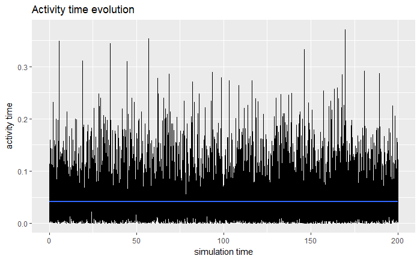

```r
#plot activity time (served time?)
plot(mmc.arrivals,metric="activity_time")
```

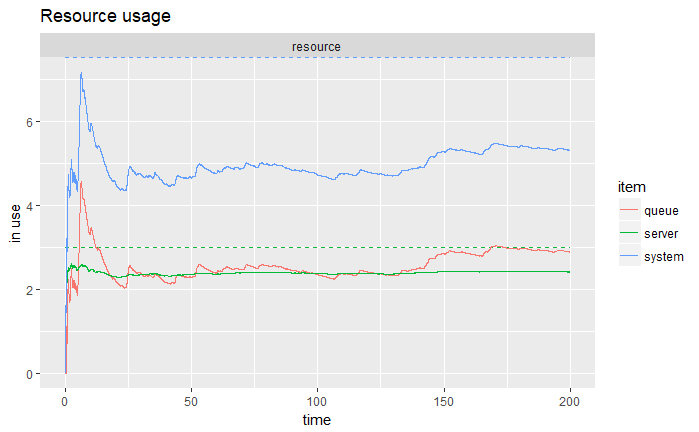

```r
#plot all resources (resources are in this case queue + servers)
plot(mmc.resources, metric="usage")
```

What can you plot with this? Look here for examples: https://r-simmer.org/extensions/plot/reference/plot.mon.html

## An M/M/c/k

An MMck is implemented in much the same way, we only need to adjust the formulas. first, purge the environment (we’ll be reusing the variable names ಠ‿ಠ)

```r
rm(list=ls())
```

Now create a new simulation environment with simmer

```r
#setting up the environment
library(simmer)
#the basic parameters for a M/M/c system
lambda <- 11
mu <- 6
c<- 5
k<-3
rho<- lambda/mu
rho_c <- lambda/(c*mu)
#set up the function that the servers use
mmc.trajectory <- trajectory() %>%
  seize("resource", amount=1) %>%
  timeout(function() rexp(1, mu)) %>%
  release("resource", amount=1)
#set up the environment with the arrival / server fuctions
#as you see exponential distributions around mu and lambda are chosen
mmc.env <- simmer() %>%
  # --- -- -- - -- - - -- - --
  #note that you can input the queue length here. right now set to a set length!.
  add_resource("resource", capacity=c, queue_size=k) %>%
  add_generator("arrival", mmc.trajectory, function() rexp(1, lambda)) %>%
  run(until=2000)
```

Now just to adjust the pesky formulas ಥ_ಥ (find them on p.652, CH13.7 of Ragsdale)

```r
# index n
ind <- 1:(c)
ind2 <- (c+1):k
#index for length
ind3 <- 0:(c-1)
#units in system. just change the upper value in the vector to one you want
nunitsm <- 1:10
# probability of empty
pi_0 <- 1/(sum(rho**ind/factorial(ind)) + (rho**c/factorial(c))*sum((1/(1-rho/c)^(ind2-c))))
#probability of n units in system
#for s < n <= k
probabilities_units <- as.data.frame(cbind(nunitsm, ((lambda/mu)^nunitsm)/(c*factorial(c)^(nunitsm-c))*pi_0))
#for n <= s
for (ci in 1:c) {
   probabilities_units$V2[ci] <- ((lambda/mu)^ci)/factorial(ci)*pi_0
}
#for n > k
probabilities_units$V2[probabilities_units$nunitsm > k] <- 0
#average lengths, of in system and in queue
#average number in queue
mmc.Lq <- (pi_0*rho^c*rho_c)/(factorial(c)*(1-rho_c)^2)*(1-rho_c^(k-c)-(k-c)*rho_c^(k-c)*(1-rho_c))
#average number in system
mmc.L <- sum(ind3*probabilities_units$V2[probabilities_units$nunitsm==ind3])+mmc.Lq+c*(1-sum(probabilities_units$V2[probabilities_units$nunitsm==ind3]))
#simulation outputs for avg waittime etc. not sure if they are correct (づ｡◕‿‿◕｡)づ
mmc.arrivals <- get_mon_arrivals(mmc.env)
mmc.resources<- get_mon_resources(mmc.env)
#avg time in system
mmc.t_system <- mmc.arrivals$end_time - mmc.arrivals$start_time
lambda_eff<-lambda
#avg wait time
mmc.W <- mmc.L / lambda_eff
mmc.W ; mean(mmc.t_system)
```

```
[1] 0.4619134
[1] 0.1703425
```

The graphs etc you can get with the functions in previous chunks.

thaat’s it! q(❂‿❂)p